# PSY T880 Course Project: Kaggle House Prices Challenge

# Introduction to the Challenge

This course project is taken from the Kaggle competition:

[House Prices: Advanced Regression Techniques](https://www.kaggle.com/c/house-prices-advanced-regression-techniques)

A lot of very talented Kagglers have already submitted their solutions, and so I’ll be sure to reference them whenever possible.

The model will be validated by the test set RMSE between $log(y)$ and $log(\hat y)$.

First, we will explore the data set to see what we have.

```r
library(tidyverse)
library(knitr)
library(e1071)
library(psych)
library(SGL)
train = read.csv("train.csv")
test = read.csv("test.csv")
test$SalePrice = rep(0,dim(test)[1])
train_index = dim(train)[1]
train = rbind(train,test)
dim(train)
```

```
[1] 2919   81
```

```r
head(train)
```

|  | Id | MSSubClass | MSZoning | LotFrontage | LotArea | Street | Alley | LotShape | LandContour | Utilities | LotConfig | LandSlope | Neighborhood | Condition1 | Condition2 | BldgType | HouseStyle | OverallQual | OverallCond | YearBuilt | YearRemodAdd | RoofStyle | RoofMatl | Exterior1st | Exterior2nd | MasVnrType | MasVnrArea | ExterQual | ExterCond | … |
| --- | --- | --- | --- | --- | --- | --- | --- | --- | --- | --- | --- | --- | --- | --- | --- | --- | --- | --- | --- | --- | --- | --- | --- | --- | --- | --- | --- | --- | --- | --- |
| 1 | 1 | 60 | RL | 65 | 8450 | Pave | NA | Reg | Lvl | AllPub | Inside | Gtl | CollgCr | Norm | Norm | 1Fam | 2Story | 7 | 5 | 2003 | 2003 | Gable | CompShg | VinylSd | VinylSd | BrkFace | 196 | Gd | TA | … |
| 2 | 2 | 20 | RL | 80 | 9600 | Pave | NA | Reg | Lvl | AllPub | FR2 | Gtl | Veenker | Feedr | Norm | 1Fam | 1Story | 6 | 8 | 1976 | 1976 | Gable | CompShg | MetalSd | MetalSd | None | 0 | TA | TA | … |
| 3 | 3 | 60 | RL | 68 | 11250 | Pave | NA | IR1 | Lvl | AllPub | Inside | Gtl | CollgCr | Norm | Norm | 1Fam | 2Story | 7 | 5 | 2001 | 2002 | Gable | CompShg | VinylSd | VinylSd | BrkFace | 162 | Gd | TA | … |
| 4 | 4 | 70 | RL | 60 | 9550 | Pave | NA | IR1 | Lvl | AllPub | Corner | Gtl | Crawfor | Norm | Norm | 1Fam | 2Story | 7 | 5 | 1915 | 1970 | Gable | CompShg | Wd Sdng | Wd Shng | None | 0 | TA | TA | … |
| 5 | 5 | 60 | RL | 84 | 14260 | Pave | NA | IR1 | Lvl | AllPub | FR2 | Gtl | NoRidge | Norm | Norm | 1Fam | 2Story | 8 | 5 | 2000 | 2000 | Gable | CompShg | VinylSd | VinylSd | BrkFace | 350 | Gd | TA | … |
| 6 | 6 | 50 | RL | 85 | 14115 | Pave | NA | IR1 | Lvl | AllPub | Inside | Gtl | Mitchel | Norm | Norm | 1Fam | 1.5Fin | 5 | 5 | 1993 | 1995 | Gable | CompShg | VinylSd | VinylSd | None | 0 | TA | TA | … |

The data has 1460 observations and 81 variables. N is far greater than P, but P is quite large and many of these variables may contribute noise to the model. Hence, good variable selection or regularisation may be necessary.

```r
names(train)
```

```
 [1] "Id"            "MSSubClass"    "MSZoning"
 [4] "LotFrontage"   "LotArea"       "Street"
 [7] "Alley"         "LotShape"      "LandContour"
[10] "Utilities"     "LotConfig"     "LandSlope"
[13] "Neighborhood"  "Condition1"    "Condition2"
[16] "BldgType"      "HouseStyle"    "OverallQual"
[19] "OverallCond"   "YearBuilt"     "YearRemodAdd"
[22] "RoofStyle"     "RoofMatl"      "Exterior1st"
[25] "Exterior2nd"   "MasVnrType"    "MasVnrArea"
[28] "ExterQual"     "ExterCond"     "Foundation"
[31] "BsmtQual"      "BsmtCond"      "BsmtExposure"
[34] "BsmtFinType1"  "BsmtFinSF1"    "BsmtFinType2"
[37] "BsmtFinSF2"    "BsmtUnfSF"     "TotalBsmtSF"
[40] "Heating"       "HeatingQC"     "CentralAir"
[43] "Electrical"    "X1stFlrSF"     "X2ndFlrSF"
[46] "LowQualFinSF"  "GrLivArea"     "BsmtFullBath"
[49] "BsmtHalfBath"  "FullBath"      "HalfBath"
[52] "BedroomAbvGr"  "KitchenAbvGr"  "KitchenQual"
[55] "TotRmsAbvGrd"  "Functional"    "Fireplaces"
[58] "FireplaceQu"   "GarageType"    "GarageYrBlt"
[61] "GarageFinish"  "GarageCars"    "GarageArea"
[64] "GarageQual"    "GarageCond"    "PavedDrive"
[67] "WoodDeckSF"    "OpenPorchSF"   "EnclosedPorch"
[70] "X3SsnPorch"    "ScreenPorch"   "PoolArea"
[73] "PoolQC"        "Fence"         "MiscFeature"
[76] "MiscVal"       "MoSold"        "YrSold"
[79] "SaleType"      "SaleCondition" "SalePrice"
```

We have the variable descriptions in a text file provided by the competition. Our outcome variable is “SalePrice”. We can start our data investigation here.

> Acknowledgement: Comprehensive data exploration is highly recommended for data scientists, but there really isn’t a formal accepted school of thought on what that means. Pedro Marcelino produced a very thorough analysis of variables in his kernel [here](https://www.kaggle.com/pmarcelino/house-prices-advanced-regression-techniques/comprehensive-data-exploration-with-python).

# Comprehensive Data Exploration

The aim here is to best understand the distributions, relationships, and any erroneous qualities of the variables. This is seperate from data cleaning (as you can’t clean a room you’re not familiar with).

Marcelino, in his kernel, recommends that a thorough analysis involve the following:

1. Understanding the problem and the variables
2. Univariate study of the outcome variable
3. Multivariate study of the predictors/features
4. Cleaning
5. Checking of assumptions

So we’ll start at the beginning: Understanding the problem.

## Understanding the Problem

From the data set, it’s clear that real estate data can be a very granular and complex problem. However, even with all the granularity you could bring to measuring every quality of a property, at the end of the day, a human being is going to make a subjective judgment on whether or not they “like” the property. So when it comes to the binary decision of sell or not sell, the data set has to somehow mimic that property. Fortunately, we are not predicting a sale, but the *Sale Price*. This means that we can use the quantitative and more objective values, but we would still need to consider that there will be some subjective measurements that would push demand and supply for property; this can’t be avoided, and so my own intuition is to put increased weight on what could be thought of as cognitive decision-based features.

I’m calling this **the behaviorist’s perspective to data analysis**, although I’m sure it’s more appropriate to just call this “domain knowledge”. It’ll help us to make sure to incorporate some of the behavioral tendencies of people in our approach to predicting Sale Price.

The features themselves are very many, and some are quite related. I’ve tried to group the related variables in the lists below:

```r
Type_of_property = c("MSSubClass", "MSZoning", "LotShape", "LotConfig", "Condition1", "Condition2", "BldgType", "HouseStyle", "GarageType", "SaleType", "MoSold", "YrSold", 'SaleCondition')
Geographic_qualities = c("LandContour", "LandSlope", "Neighborhood")
Subjective_measures= c("OverallQual", "OverallCond", "ExterQual", "ExterCond", "BsmtQual", "BsmtCond", "BsmtExposure", "BsmtFinType1", "BsmtFinType2", "HeatingQC", "KitchenQual", "Functional", "FireplaceQu", "GarageFinish", "GarageQual", "GarageCond", "PoolQC", "Fence")
Physical_amenities= c("Street", "Alley", 'Utilities', "RoofStyle", "RoofMatl", "Exterior1st", "Exterior2nd", "MasVnrType", "Foundation", "Heating", "CentralAir", "Electrical", "BsmtFullBath", "BsmtHalfBath", "FullBath", "HalfBath", "Bedroom", "Kitchen", "TotRmsAbvGrd", "Fireplaces", "PavedDrive", "MiscFeature")
Quantitative_measures= c("LotFrontage", "LotArea", "YearBuilt", "YearRemodAdd", "MasVnrArea", "BsmtFinSF1", "BsmtFinSF2", "BsmtUnfSF", "TotalBsmtSF", "1stFlrSF", "2ndFlrSF", "GrLivArea", "GarageYrBlt", "GarageCars", "GarageArea", "OpenPorchSF", "WoodDeckSF", "EnclosedPorch", "3SsnPorch", "ScreenPorch", "PoolArea", "MiscVal")
```

## The Outcome: SalesPrice

Let’s start by simply visualising the variable.

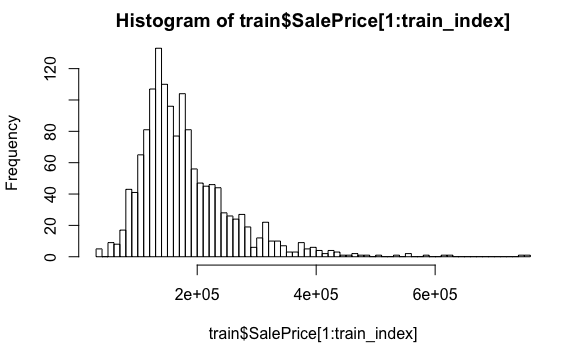

```r
hist(train$SalePrice[1:train_index], breaks = 100)
```

With this level of breaks, there is a clear skew with this variable. It has a heavy right tail. We can check just how skewed this is:

```r
skewness(train$SalePrice[1:train_index])
```

```
[1] 1.879009
```

```r
kurtosis(train$SalePrice[1:train_index])
```

```
[1] 6.496789
```

It’s relatively skewed, but not obscenely non-normal. This problem might therefore lend itself to a non-linear prediction method, but linear methods may perform relatively well. Alternately, we can see if outliers tell us more about the data.

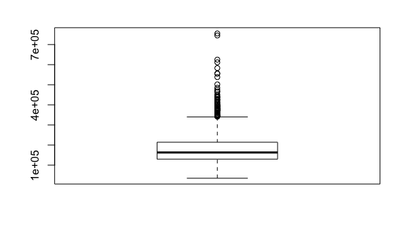

```r
boxplot(train$SalePrice[1:train_index])
```

From this plot, it’s clear that there are a number of statistical outliers, but all on the right end of the distribution. Like above, this is not a case where deleting outliers would help.

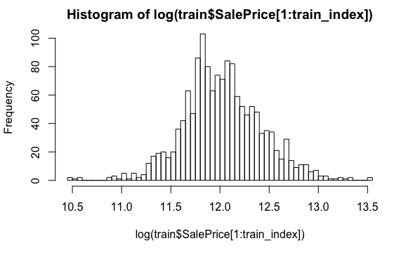

```r
hist(log(train$SalePrice[1:train_index]), breaks = 100)
```

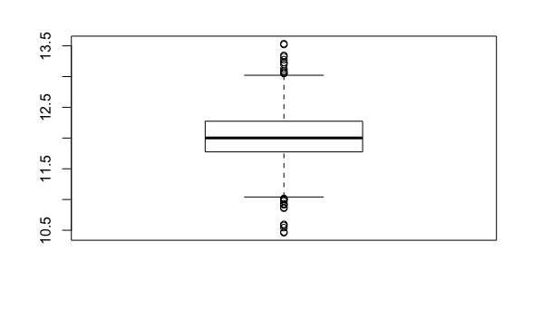

```r
boxplot(log(train$SalePrice[1:train_index]))
```

With these plots, we can see that log-transforming the outcome variable creates a distribution that is far more normal and has outliers on either end of the range; it would be worth investigating whether or not the outliers are represented significantly in any particular variables (such as whether they are mansions or penthouses of some kind).

## Missing Data & Needless Variables

Missing data can be problematic, and we usually deal with it by removing rows with incomplete data. With this many variables, it might be useful to cut down on the implications by just taking out any variables that are probably not going to tell us anything and not be useful in the regression problem. A useful way to do this is to see how many missing values might be in each variable and delete those that contribute too much missingness.

```r
nas = train[,sapply(train, anyNA)]
summary(nas)
```

```
    MSZoning     LotFrontage      Alley       Utilities
 C (all):  25   Min.   : 21.00   Grvl: 120   AllPub:2916
 FV     : 139   1st Qu.: 59.00   Pave:  78   NoSeWa:   1
 RH     :  26   Median : 68.00   NA's:2721   NA's  :   2
 RL     :2265   Mean   : 69.31
 RM     : 460   3rd Qu.: 80.00
 NA's   :   4   Max.   :313.00
                NA's   :486
  Exterior1st    Exterior2nd     MasVnrType
 VinylSd:1025   VinylSd:1014   BrkCmn :  25
 MetalSd: 450   MetalSd: 447   BrkFace: 879
 HdBoard: 442   HdBoard: 406   None   :1742
 Wd Sdng: 411   Wd Sdng: 391   Stone  : 249
 Plywood: 221   Plywood: 270   NA's   :  24
 (Other): 369   (Other): 390
 NA's   :   1   NA's   :   1
   MasVnrArea     BsmtQual    BsmtCond    BsmtExposure
 Min.   :   0.0   Ex  : 258   Fa  : 104   Av  : 418
 1st Qu.:   0.0   Fa  :  88   Gd  : 122   Gd  : 276
 Median :   0.0   Gd  :1209   Po  :   5   Mn  : 239
 Mean   : 102.2   TA  :1283   TA  :2606   No  :1904
 3rd Qu.: 164.0   NA's:  81   NA's:  82   NA's:  82
 Max.   :1600.0
 NA's   :23
 BsmtFinType1   BsmtFinSF1     BsmtFinType2   BsmtFinSF2
 ALQ :429     Min.   :   0.0   ALQ :  52    Min.   :   0.00
 BLQ :269     1st Qu.:   0.0   BLQ :  68    1st Qu.:   0.00
 GLQ :849     Median : 368.5   GLQ :  34    Median :   0.00
 LwQ :154     Mean   : 441.4   LwQ :  87    Mean   :  49.58
 Rec :288     3rd Qu.: 733.0   Rec : 105    3rd Qu.:   0.00
 Unf :851     Max.   :5644.0   Unf :2493    Max.   :1526.00
 NA's: 79     NA's   :1        NA's:  80    NA's   :1
   BsmtUnfSF       TotalBsmtSF     Electrical
 Min.   :   0.0   Min.   :   0.0   FuseA: 188
 1st Qu.: 220.0   1st Qu.: 793.0   FuseF:  50
 Median : 467.0   Median : 989.5   FuseP:   8
 Mean   : 560.8   Mean   :1051.8   Mix  :   1
 3rd Qu.: 805.5   3rd Qu.:1302.0   SBrkr:2671
 Max.   :2336.0   Max.   :6110.0   NA's :   1
 NA's   :1        NA's   :1
```

[output cut: 25 more lines]

```
 Ex  :   3   Ex  :   4   GdPrv: 118   Gar2:   5
 Fa  :  74   Fa  :   2   GdWo : 112   Othr:   4
 Gd  :  15   Gd  :   4   MnPrv: 329   Shed:  95
 Po  :  14   NA's:2909   MnWw :  12   TenC:   1
 TA  :2654               NA's :2348   NA's:2814
 NA's: 159

    SaleType
 WD     :2525
 New    : 239
 COD    :  87
 ConLD  :  26
 CWD    :  12
 (Other):  29
 NA's   :   1
```

To start off, only 81 houses (6%) don’t have garages. I feel like this would significantly reduce the sale price, but at only 6% of the data, it’s probably best to remove these.

```r
ind = is.na(train$GarageYrBlt)
train = train[ind == FALSE,]
nas = train[,sapply(train, anyNA)]
```

Similarly, there are only 30 NAs for basement variabeles and masonry variables. We can scrap these too.

```r
ind = is.na(train$BsmtExposure)
train = train[ind == FALSE,]
ind = is.na(train$MasVnrType)
train = train[ind == FALSE,]
nas = train[,sapply(train, anyNA)]
```

We can also get rid of the remaining rows where there are very few NAs

```r
train = train[is.na(train$Electrical) == FALSE,]
train = train[is.na(train$BsmtFinType2) == FALSE,]
nas = train[,sapply(train, anyNA)]
```

### Alleys

Now we have a handful of variables with NAs that may be useful to look at. The first, Alley; it may not have that much importance. We can plot alley’s against the outcome variable to see:

```r
levels(train$Alley) = c(levels(train$Alley), "None")
train$Alley[is.na(train$Alley) == TRUE] = "None"
boxplot(train$SalePrice~train$Alley)
```

[output not shown]

It looks like most of the cheaper properties have gravel or pavement alleys; the expensive properties do have them, but the outliers particularly account for no alleyway. My intuition tells me that we should binarise this variable instead of ditch it, because the outlier distribution may be useful information. *This is our first example of feature engineering.*

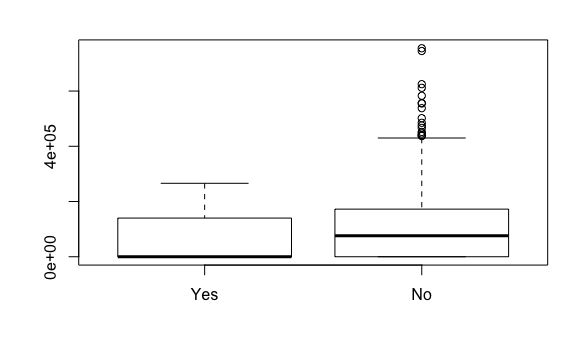

```r
levels(train$Alley) = c("Yes", "Yes", "No")
boxplot(train$SalePrice~train$Alley)
```

### Quality Measures

`Pool Quality` has far too many NAs for it to be useful at this point, as do `Fence` and `MiscFeature` (although miscellaneous features such as sheds and second garages are almost guaranteed to spike the price).

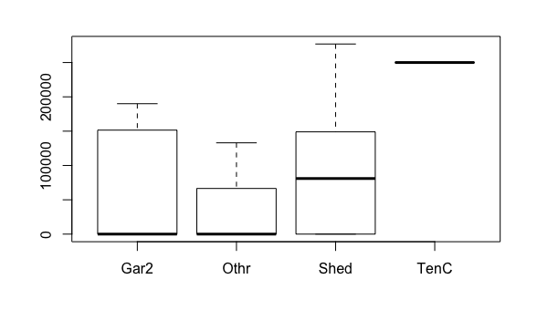

```r
toRemove = c("PoolQC")
plot(factor(train$MiscFeature), train$SalePrice)
```

Tennis courts definitely increase the price. Let’s investigate `MiscVal` as it is a likely strong measure.

We can check if the outliers in the outcome variable are represented by these miscellaneous features:

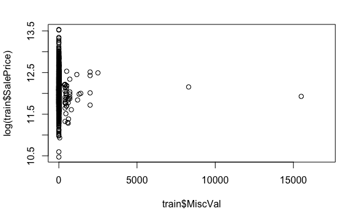

```r
plot(train$MiscVal,log(train$SalePrice))
```

Nope. This is likely not a useful measure.

Let’s ditch it, and instead use the binary measure suggested before.

```r
toRemove = c(toRemove, "MiscVal")
levels(train$MiscFeature) = c("Y","Y", "Y", "Y", "N")
train$MiscFeature[is.na(train$MiscFeature)] = "N"
```

Fireplaces have quality scores, but they are not ultimately more useful than just having the number of fireplaces (I don’t assume people think a great deal about the state of the fireplace unless it’s in bad shape). Instead, we will just calculate a new variable for this aspect as a new feature, `FPScore`.

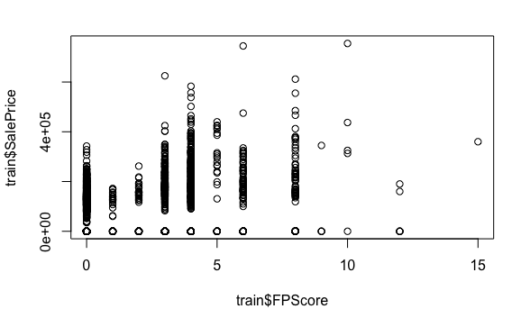

```r
fp2 = NULL
fp2[train$FireplaceQu == "Ex"] = 5
fp2[train$FireplaceQu == "Gd"] = 4
fp2[train$FireplaceQu == "TA"] = 3
fp2[train$FireplaceQu == "Fa"] = 2
fp2[train$FireplaceQu == "Po"] = 1
fp2[is.na(train$FireplaceQu)] = 0
train$FPScore = (fp2)*(train$Fireplaces)
toRemove = c(toRemove, "FireplaceQu", "Fireplaces")
plot(train$FPScore,train$SalePrice)
```

```r
cor(train$FPScore,train$SalePrice)
```

```
[1] 0.2141936
```

`Fence` is an interesting variable. We can assume that good fences go with good homes, but more importantly, good fences come with certain types of neighbourhouds. Let’s investigate this:

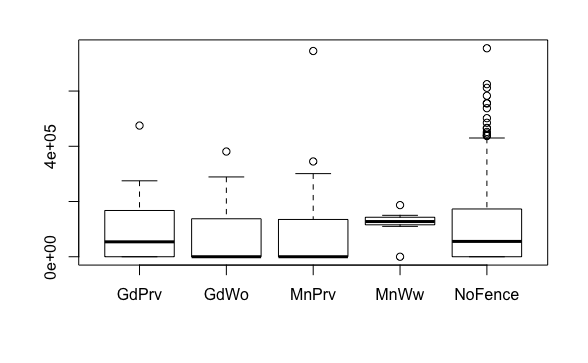

```r
levels(train$Fence) = c(levels(train$Fence), "NoFence")
train$Fence[is.na(train$Fence)] = "NoFence"
boxplot(train$SalePrice~train$Fence)
```

[output not shown]

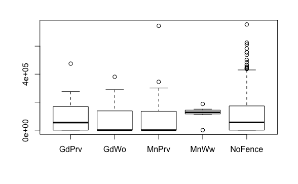

```r
boxplot(train$SalePrice~train$Fence)$stats
```

[output not shown]

However, since `Fence` is not likert-like, we can’t neessarily use it in a numerical manner. It will remain categorical.

The remaining variable with a bunch of NAs is `LotFrontage`, referring to the linear feet of street connected to the property.

```r
summary(train$LotFrontage[1:train_index])
```

```
   Min. 1st Qu.  Median    Mean 3rd Qu.    Max.    NA's
  21.00   59.00   69.00   70.05   80.00  313.00     259
```

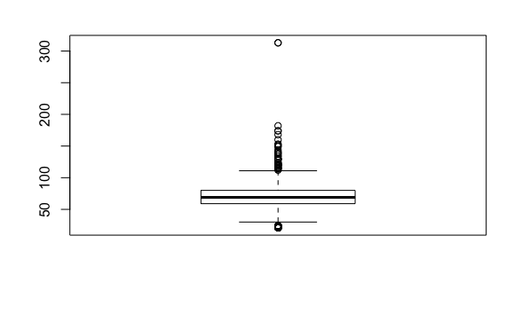

```r
boxplot(train$LotFrontage[1:train_index])
```

This is a strictly numerical variable. Is it possible that homes can have *no street* directly connected to the property? Should NAs represent zero?

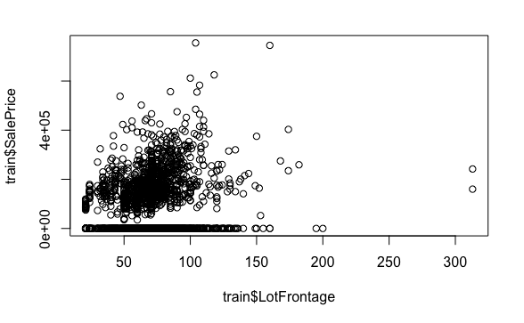

```r
train$LotFrontage[is.na(train$LotFrontage)] = 70.76
plot(train$LotFrontage, train$SalePrice)
```

```r
cor(train$LotFrontage, train$SalePrice)
```

```
[1] 0.1540997
```

It’s a weak correlation, but we’ll keep it.

## Subjective Scores

We’ve already seen how combining the number of fireplaces with the fireplace quality improves the correlation between this score and the sale price. Even if it is marginal, it’s useful in these types of problems. We’ll see if we can’t combine a few other variables, i.e., engineer some more features, that use subjective scores.

**Subjective measures:** OverallQual, OverallCond, ExterQual, ExterCond, BsmtQual, BsmtCond, BsmtExposure, BsmtFinType1, BsmtFinType2, HeatingQC, KitchenQual, Functional, FireplaceQu, GarageFinish, GarageQual, GarageCond, PoolQC, Fence

The first is the overall quality and condition.

```r
cor(train$OverallCond, train$OverallQual)
```

```
[1] -0.09384734
```

Surprisingly, these two are not correlated.

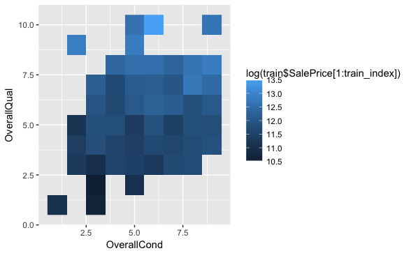

```r
gg = ggplot(data = train[1:train_index,])
gg + geom_raster(aes(OverallCond, OverallQual, fill = log(train$SalePrice[1:train_index])))
```

The plot seems to only slightly tend towards having higher expense for higher condition, but definitely higher price for higher quality. We can keep these seperate.

We can check the same for the external quality and condition. In this case, we definitely want to treat this as a pseudo continuous Likert scale.

```r
ext1 = NULL
ext2 = NULL
ext1[train$ExterQual == "Ex"] = 5
ext1[train$ExterQual == "Gd"] = 4
ext1[train$ExterQual == "TA"] = 3
ext1[train$ExterQual == "Fa"] = 2
ext1[train$ExterQual == "Po"] = 1
ext1[is.na(train$ExterQual)] = 0
ext2[train$ExterCond == "Ex"] = 5
ext2[train$ExterCond == "Gd"] = 4
ext2[train$ExterCond == "TA"] = 3
ext2[train$ExterCond == "Fa"] = 2
ext2[train$ExterCond == "Po"] = 1
ext2[is.na(train$ExterCond)] = 0
cor(ext1, train$SalePrice)
```

```
[1] 0.2507717
```

```r
cor(ext2, train$SalePrice)
```

```
[1] 0.001888145
```

```r
cor(ext1, ext2)
```

```
[1] 0.02985199
```

```r
train$ExtScore = (ext1)/(ext2)
cor(train$ExtScore, train$SalePrice)
```

```
[1] 0.201647
```

```r
gg + geom_raster(aes(ExterCond, ExterQual, fill = log(train$SalePrice[1:train_index])))
toRemove = c(toRemove, "ExtScore")
```

[output not shown]

There’s a higher correlation coefficient between External quality alone than there is between a combination of the two measures, so we keep them both seperate.

Now Basement quality and condition.

```r
bsm1 = NULL
bsm2 = NULL
bsm1[train$BsmtQual == "Ex"] = 5
bsm1[train$BsmtQual == "Gd"] = 4
bsm1[train$BsmtQual == "TA"] = 3
bsm1[train$BsmtQual == "Fa"] = 2
bsm1[train$BsmtQual == "Po"] = 1
bsm1[is.na(train$BsmtQual)] = 0
bsm2[train$BsmtCond == "Ex"] = 5
bsm2[train$BsmtCond == "Gd"] = 4
bsm2[train$BsmtCond == "TA"] = 3
bsm2[train$BsmtCond == "Fa"] = 2
bsm2[train$BsmtCond == "Po"] = 1
bsm2[is.na(train$BsmtCond)] = 0
cor(bsm1, train$SalePrice)
```

```
[1] 0.2220657
```

```r
cor(bsm2, train$SalePrice)
```

```
[1] 0.100499
```

```r
cor(bsm1, bsm2)
```

```
[1] 0.6251575
```

```r
train$BsmScore = (bsm1)+(bsm2)
cor(train$BsmScore, train$SalePrice)
```

```
[1] 0.1928663
```

```r
gg + geom_raster(aes(BsmtCond, BsmtQual, fill = log(train$SalePrice[1:train_index])))
toRemove = c(toRemove, "BsmScore")
```

[output not shown]

Once again, quality is more strongly correlated with the sale price than condition. We may be able to drop all condition variables, if their values are not strongly correlated enough.

Now Garage quality and condition.

```r
grg1 = NULL
grg2 = NULL
grg1[train$GarageQual == "Ex"] = 5
grg1[train$GarageQual == "Gd"] = 4
grg1[train$GarageQual == "TA"] = 3
grg1[train$GarageQual == "Fa"] = 2
grg1[train$GarageQual == "Po"] = 1
grg1[is.na(train$GarageQual)] = 0
grg2[train$GarageCond == "Ex"] = 5
grg2[train$GarageCond == "Gd"] = 4
grg2[train$GarageCond == "TA"] = 3
grg2[train$GarageCond == "Fa"] = 2
grg2[train$GarageCond == "Po"] = 1
grg2[is.na(train$GarageCond)] = 0
cor(grg1, train$SalePrice)
```

```
[1] 0.09702617
```

```r
cor(grg2, train$SalePrice)
```

```
[1] 0.0544529
```

```r
cor(grg1, grg2)
```

```
[1] 0.538139
```

```r
train$GrgScore = (grg2+1)*(grg1+1)
cor(train$GrgScore, train$SalePrice)
```

```
[1] 0.08896836
```

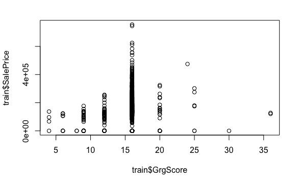

```r
plot(train$GrgScore, train$SalePrice)
```

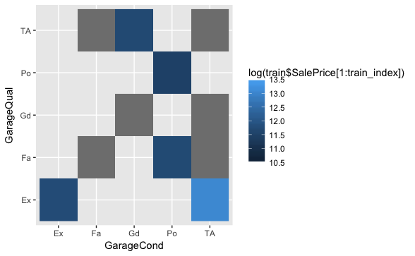

```r
gg + geom_raster(aes(GarageCond, GarageQual, fill = log(train$SalePrice[1:train_index])))
```

```r
toRemove = c(toRemove, "GrgScore")
```

In this case, the individual garage scores are poorly correlated alone, but highly colinear. It would be a worthwhile pursuit to find some composite measure that would be strongly correlated with the outcome.

Unfortunately, it’s only possible to maximise this correlation to about 0.14, which is not strong so may probably not be useful. We’ll not use it.

```r
toRemove = c(toRemove, "GrgScore", "GarageQual", "GarageCond")
```

## The Continuous Variables

Here we examine distributions of the continous variables.

```r
toRemove = c(toRemove, "Id")
cont = train[1:train_index,sapply(train,is.numeric)]
sapply(cont, summary)
```

```
$Id
   Min. 1st Qu.  Median    Mean 3rd Qu.    Max.
    1.0   365.8   730.5   730.5  1095.0  1460.0

$MSSubClass
   Min. 1st Qu.  Median    Mean 3rd Qu.    Max.
   20.0    20.0    50.0    56.9    70.0   190.0

$LotFrontage
   Min. 1st Qu.  Median    Mean 3rd Qu.    Max.
  21.00   60.00   70.76   70.18   79.00  313.00

$LotArea
   Min. 1st Qu.  Median    Mean 3rd Qu.    Max.
   1300    7554    9478   10520   11600  215200

$OverallQual
   Min. 1st Qu.  Median    Mean 3rd Qu.    Max.
  1.000   5.000   6.000   6.099   7.000  10.000

$OverallCond
   Min. 1st Qu.  Median    Mean 3rd Qu.    Max.
  1.000   5.000   5.000   5.575   6.000   9.000

$YearBuilt
   Min. 1st Qu.  Median    Mean 3rd Qu.    Max.
   1872    1954    1973    1971    2000    2010

$YearRemodAdd
   Min. 1st Qu.  Median    Mean 3rd Qu.    Max.
   1950    1967    1994    1985    2004    2010

$MasVnrArea
   Min. 1st Qu.  Median    Mean 3rd Qu.    Max.    NA's
    0.0     0.0     0.0   103.7   166.0  1600.0       8

$BsmtFinSF1
   Min. 1st Qu.  Median    Mean 3rd Qu.    Max.
    0.0     0.0   383.5   443.6   712.2  5644.0

```

[output cut: 108 more lines]

```
$SalePrice
   Min. 1st Qu.  Median    Mean 3rd Qu.    Max.
  34900  130000  163000  180900  214000  755000

$FPScore
   Min. 1st Qu.  Median    Mean 3rd Qu.    Max.
  0.000   0.000   2.000   2.126   4.000  15.000

$ExtScore
   Min. 1st Qu.  Median    Mean 3rd Qu.    Max.
  0.600   1.000   1.000   1.114   1.333   3.000

$BsmScore
   Min. 1st Qu.  Median    Mean 3rd Qu.    Max.
  0.000   6.000   7.000   6.424   7.000   9.000
```

```r
skews = sapply(cont, skewness)
summary(skews)
```

```
   Min. 1st Qu.  Median    Mean 3rd Qu.    Max.    NA's
-2.9230  0.2141  0.9184  2.8080  2.7230 24.4300       2
```

This short analysis tells us that there are a number of variables with a great amount of skew (normally distirbuted variables should be around zero, the mean skewness for the data set is actually around 2.8).

We should probably log transform all of the continuous variables in this case.

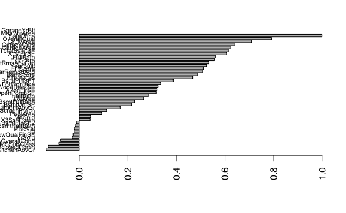

```r
cors = cor(cont)[,"SalePrice"]
cors = cors[order(cors)]
par(las = 2)
barplot(cors, horiz = T, cex.names = 0.65)
```

Instead of looking randomly at variables, maybe the task should be to work incrementally from the mid-and low-correlated variables to see if we could increase their linear correlation with the outcome. We’ll assess those with correlation less than 0.3

```r
cors[cors < 0.3]
```

[output not shown]

It doesn’t make sense for overall condition to be negatively correlated with sale price.

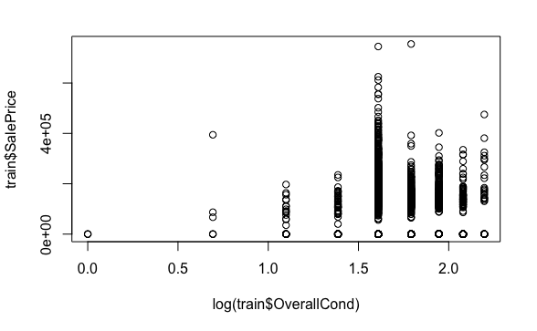

```r
plot(log(train$OverallCond), train$SalePrice)
```

```r
cor(train$OverallCond, log(train$SalePrice))
```

```
[1] NaN
```

What’s probably happening is that the outliers are skewing this variable terribly. We could take care of this in a detailed manner, but time is of the essence.

## The Categorical Variables

```r
cat = train[,!(sapply(train,is.numeric))]
names(cat)
```

```
 [1] "MSZoning"      "Street"        "Alley"
 [4] "LotShape"      "LandContour"   "Utilities"
 [7] "LotConfig"     "LandSlope"     "Neighborhood"
[10] "Condition1"    "Condition2"    "BldgType"
[13] "HouseStyle"    "RoofStyle"     "RoofMatl"
[16] "Exterior1st"   "Exterior2nd"   "MasVnrType"
[19] "ExterQual"     "ExterCond"     "Foundation"
[22] "BsmtQual"      "BsmtCond"      "BsmtExposure"
[25] "BsmtFinType1"  "BsmtFinType2"  "Heating"
[28] "HeatingQC"     "CentralAir"    "Electrical"
[31] "KitchenQual"   "Functional"    "FireplaceQu"
[34] "GarageType"    "GarageFinish"  "GarageQual"
[37] "GarageCond"    "PavedDrive"    "PoolQC"
[40] "Fence"         "MiscFeature"   "SaleType"
[43] "SaleCondition"
```

```r
all_cat = NULL
for(i in 1:length(names(cat))){
  dummy <- dummy.code(cat[,i])
  all_cat = cbind(all_cat,dummy)
}
all_cat = as.data.frame(all_cat)
```

The categoricals, when extracted, create 251 dummy variables.

# Fitting a sparse group lasso

```r
cont_group = 1:length(cont)
for(i in 1:length(cont_group)){
  if(names(cont)[i] %in% Type_of_property){
    cont_group[i] = 1
  }else if(names(cont)[i] %in% Geographic_qualities){
    cont_group[i] = 2
  }else if(names(cont)[i] %in% Subjective_measures){
    cont_group[i] = 3
  }else if(names(cont)[i] %in% Physical_amenities){
    cont_group[i] = 4
  }else if(names(cont)[i] %in% Quantitative_measures){
    cont_group[i] = 5
  }else{
    cont_group[i] = 6
  }
}
cat_group = 1:length(cat)
for(i in 1:length(cat_group)){
  if(names(cat)[i] %in% Type_of_property){
    cat_group[i] = 1
  }else if(names(cat)[i] %in% Geographic_qualities){
    cat_group[i] = 2
  }else if(names(cat)[i] %in% Subjective_measures){
    cat_group[i] = 3
  }else if(names(cat)[i] %in% Physical_amenities){
    cat_group[i] = 4
  }else if(names(cat)[i] %in% Quantitative_measures){
    cat_group[i] = 5
  }else{
    cat_group[i] = 6
  }
}
all_cat_group = NULL
for(i in 1:length(cat_group)){
  temp = levels(cat[,i])%>%
    length()%>%
    rep(cat_group[i],.)
  all_cat_group = c(all_cat_group, temp)
}
groups = c(cont_group, all_cat_group)
```

```r
dat = data.frame(cbind(cont,all_cat))
dat1 = dat[1:train_index,]
dat1 = dat1[complete.cases(dat1),]
zeros = as.vector(colSums(dat1))
zeros = zeros != 0
zeros[c(1,38)] = FALSE
groups = groups[zeros]
Y = log(dat1$SalePrice+0.00001)
X = dat1[,zeros]
data = list(x = X,y = Y)
sgl1 = SGL(data = data, index = groups, type = "linear")
```

[figure not shown]

```r
for(i in 2:21){
  temp = data.frame(Id = submission[,1], SalePrice = submission[,i])
  write.table(temp,file = paste(colnames(submission)[i],".csv", sep = ""),dec = ".", sep = ",", row.names = F)
}
```

Here are the results, using the RMSE of log(actual) and log(predicted):

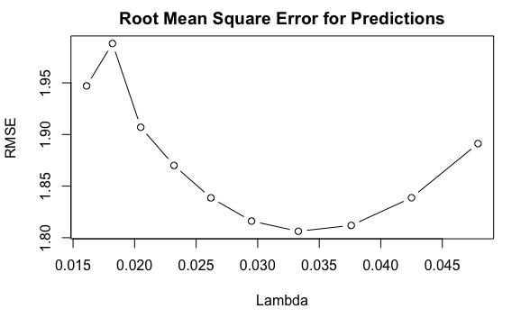

```r
results = data.frame(Lambda = c(0.0479,0.0425,0.0376,0.0333, 0.0295, 0.0262, 0.0232, 0.0205, 0.0182, 0.0161)
                       , RMSE = c(1.89118,1.83875, 1.81195, 1.80625, 1.81615, 1.83865, 1.87002, 1.90702,1.98818,1.94706))
plot(results, type = "b", main = "Root Mean Square Error for Predictions")
```

We can check the coefficients of this best performer:

|  | Variables | Coefficients | Lambda |
| --- | --- | --- | --- |
| 1179 | MoSold | 0.1736975 | 5 |
| 1180 | YrSold | -40.1858391 | 5 |